# Tidymodel_Build a Model

Sangmin Je

2021 4 15

> 본 문서는 Tidymodel에 대해 공부하고 프로세스를 익히는 것에 목적이 있습니다.
- 먼저 **TidyModel**을 접하고 생각한 것은 ’와 정말 많이 편하게 만드려고 노력했구나’였다. 예를 들어서 이전에는 **로지스틱회귀분**석과 **RandomForest**의 모델링을 위해서는 전혀 다른 패키지와 전혀다른 프로세스를 태워야 했다. 하지만 지금 Tidymodel에서는 몇 가지 공통된 패키지에서 여러 모델들을 해결할 수 있다는 장점이 있다.
- 데이터분석을 공부함에 있어서 **R**을 선택해야 할 지 **파이썬**을 선택해야 할 지 고민의 기로에 섰던 때가 있다. 사실 지금 시점에서 데이터분석을 하자면, 다른 사람이 만든 코드의 해석을 위해서라도 파이썬을 공부해야 하는 위치에 있긴 하지만, 어쨌든 **R**만으로도 부족함 없이 데이터 분석을 할 수 있을 것이라는 생각이 확연히 들었다.
- 본 서는 https://www.tidymodels.org/start/models/의 내용을 요약했다. 영어로 되어 있는 내용을 옮기는 수준이지만, 그 안에서 내가 느낀 궁금증을 좀더 정리해볼 예정이다.
- 모든 공부에 기본베이스는 필요하지만, 어느 정도 배우고 나서는 꼭 수학공식 배우듯이 밑에서부터 쌓아야 할 이유는 없다고 본다. 직접 업무를 수행하듯이 하면서 필요한 것들을 끼워넣으며 배우는 게 더욱 실무에는 효율적인 방법이라고 생각한다. 그래서 앞으로는 머신러닝을 **Tidymodel**로 풀어가면서 중간중간 마주치는 통계개념과 방법론을 정리해나갈 생각이다.

## 1. 라이브러리 부르기

```r
library(tidymodels)
# Helper packages
library(readr)       # for importing data
library(broom.mixed) # for converting bayesian models to tidy tibbles
library(dotwhisker)  # for visualizing regression results
```

- `tidymodel` 우리의 메인패키지, `parsnip` 이라는 패키지를 통해 모델링을 돕는다.
- `readr` 패키지는 테이블 형태의 데이터를 좀더 친숙하고 편하게 불러들이기 위해 사용한다. https://cran.r-project.org/web/packages/readr/readme/README.html

## 2. 데이터로드

```r
urchins <-
  read_csv("https://tidymodels.org/start/models/urchins.csv") %>%
  setNames(c("food_regime", "initial_volume", "width")) %>%
  mutate(food_regime = factor(food_regime, levels = c("Initial", "Low", "High")))
```

1. 데이터 소개
- **urchins**데이터는 성게와 관련된 데이터
  - **initial_volume** : 성게의 초기 사이즈
  - **food_regime** : 먹이를 주는 그룹의 분류
  - **width** : 성체의 사이즈, 여기서는 종속변수가 된다.
2. `setNames` 함수를 `%>%`를 통해 적용하여 데이터의 이름을 바꿔줬다. 원래는 TREAT,IV,SUTW를 Column Name으로 하는 데이터이다. 벡터화시켜서 차례대로 적용된 것을 확인할 수 있다.
3. `mutate`를 통해서 character를 factor로 데이터 타입 변경
4. **urchins** 데이터는 `tibble` 형태임. tibble은 Data.Frame보다 더 정리된 형태이며 tidyverse의 패키지와 상호호환되기 좋은 데이터 형태

## 3. 시각화

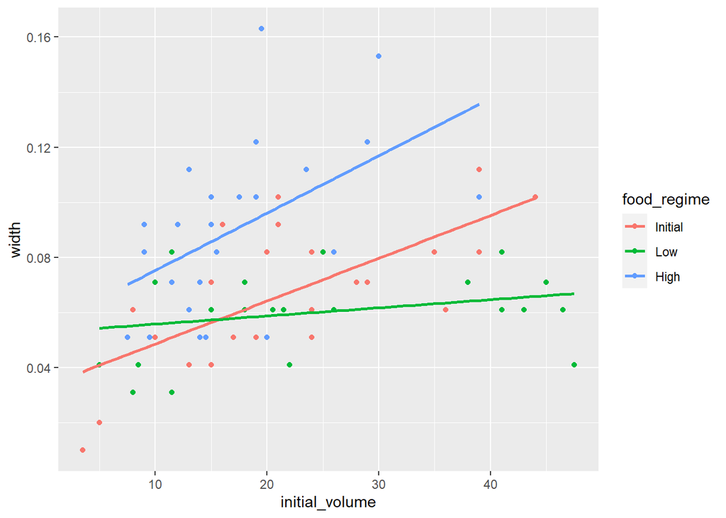

```r
urchins %>%
  ggplot(aes(x = initial_volume, y = width, col = food_regime))+
  geom_point() +
  geom_smooth(method = lm, se = F)
```

1. 시각화 결과 **initial_volume**에 따른 **width**크기의 변화가 분명히 존재하며, **food_regime**에 따라서 기울기가 다르게 나타남을 알 수 있다.

## 4. 모델 만들기

`width ~ initial_volume *food_regime`  
위와 같은 형태로 데이터를 짜면 food_regime에 따라서 각각의 기울기(slope)와 절편(intercept)을 구할 수 있다.이제 여기서 [parsnip](https://parsnip.tidymodels.org/) 패키지를 사용하자. 우리는 **Regression** 즉 예측값을 추정해보고 싶으므로 **회귀분석(Linear Regression)**을 시행한다.

```r
lr_mod <-
  linear_reg() %>%  # 모델 특정하기
  set_engine('lm')
```

1. 먼저 모델을 선언해준다. 여기서는 `linear_reg()`이라고 선형귀모델을 선언했다.
2. [set engine](https://parsnip.tidymodels.org/reference/set_engine.html)은 어떤 패키지나 컴퓨팅시스템을 통해서 모델을 훈련시킬 것인지 지정하는 것이다.

```r
lm_fit <-
  lr_mod %>%
  fit(width ~ initial_volume*food_regime, data = urchins)

tidy(lm_fit)
```

```
## # A tibble: 6 x 5
##   term                            estimate std.error statistic  p.value
##   <chr>                              <dbl>     <dbl>     <dbl>    <dbl>
## 1 (Intercept)                     0.0331    0.00962      3.44  0.00100
## 2 initial_volume                  0.00155   0.000398     3.91  0.000222
## 3 food_regimeLow                  0.0198    0.0130       1.52  0.133
## 4 food_regimeHigh                 0.0214    0.0145       1.47  0.145
## 5 initial_volume:food_regimeLow  -0.00126   0.000510    -2.47  0.0162
## 6 initial_volume:food_regimeHigh  0.000525  0.000702     0.748 0.457
```

1.`fit()`을 통해서 모델을 쉽게 fitting 가능하다. 2. `tidy`함수를 통해서 피팅한 결과를 깔끔한 테이블 형태로 볼 수 있다.

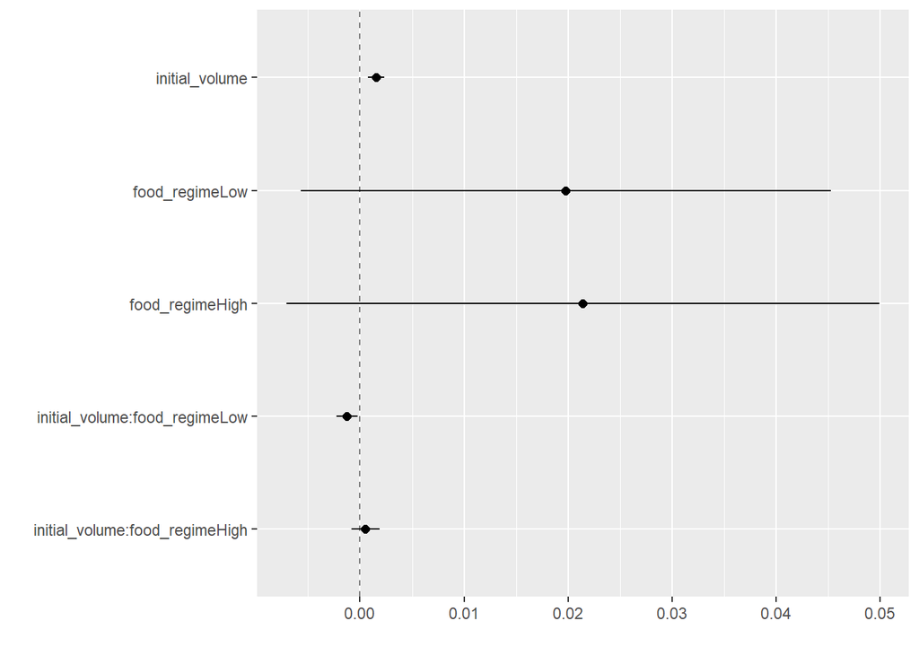

```r
tidy(lm_fit) %>%
  dwplot(dot_args = list(size = 2, color = "black"),
         whisker_args = list(color = "black"),
         vline = geom_vline(xintercept = 0, colour = "grey50", linetype = 2))
```

1. `dwplot`은 dot-whisker-plot의 약자이다. 이 plot은 fitting한 모델의 coefficient estimate의 결과를 점으로, 95% 신뢰구간을 whisker(수염)으로 표현해준다.
2. 하지만 이 그래프만을 보고 **P-Value**, 즉 유효성을 볼 수는 없는 것처럼 보인다.
3. [참고자료](https://cran.r-project.org/web/packages/dotwhisker/vignettes/dotwhisker-vignette.html)

## 5. Prediction

**urnchins**데이터는 lm_fit 객체 안에 학습되어있다. 이를 바탕으로 새로운 데이터가 있다고 가정해보자

```r
new_points <- expand.grid(initial_volume =20,
                          food_regime = c('Initial','Low','High'))
new_points
```

```
##   initial_volume food_regime
## 1             20     Initial
## 2             20         Low
## 3             20        High
```

1. `expand.grid`함수는 data.frame을 만들어주는 함수이다. 그냥 `data.frame`과 다른점은 factor를 기준으로 데이터를 여러 번 반복해서 출력해준다는 점이다. 아래 예시를 통해서 보면 차이점이 확연해진다.

```r
data.frame(x=1:5, y=letters[1:5])
```

```
##   x y
## 1 1 a
## 2 2 b
## 3 3 c
## 4 4 d
## 5 5 e
```

```r
expand.grid(x=1:5, y=letters[1:5])
```

```
##    x y
## 1  1 a
## 2  2 a
## 3  3 a
## 4  4 a
## 5  5 a
## 6  1 b
## 7  2 b
## 8  3 b
## 9  4 b
## 10 5 b
## 11 1 c
## 12 2 c
## 13 3 c
## 14 4 c
## 15 5 c
## 16 1 d
## 17 2 d
## 18 3 d
## 19 4 d
## 20 5 d
## 21 1 e
## 22 2 e
## 23 3 e
## 24 4 e
## 25 5 e
```

**Tidymodel**에서는 predicted_value, 즉 예측값의 포멧이 똑같다.

```r
mean_pred <- predict(lm_fit, new_data = new_points)
mean_pred
```

```
## # A tibble: 3 x 1
##    .pred
##    <dbl>
## 1 0.0642
## 2 0.0588
## 3 0.0961
```

1. **tibble**은 언제나 정리된 데이터 형식을 출력한다. 고로 `predict`의 값들도 정해진 포멧이 있다. 이렇게 포멧이 통일되어 있으면, 언제든 다른 방법으로 만들어낸 데이터와 Combine하여 결과를 보기 좋은 점이 있다.

```r
conf_int_pred <- predict(lm_fit,
                         new_data = new_points,
                         type = 'conf_int')
conf_int_pred
```

```
## # A tibble: 3 x 2
##   .pred_lower .pred_upper
##         <dbl>       <dbl>
## 1      0.0555      0.0729
## 2      0.0499      0.0678
## 3      0.0870      0.105
```

```r
# Combine Data
bind_cols(new_points,mean_pred, conf_int_pred)
```

```
##   initial_volume food_regime      .pred .pred_lower .pred_upper
## 1             20     Initial 0.06421443  0.05549934  0.07292952
## 2             20         Low 0.05880940  0.04986251  0.06775629
## 3             20        High 0.09613343  0.08696233  0.10530453
```

1. **conf_int_pred**라는 객체에 신뢰구간을 부여했다.
2. 여기서 `bind_cols`함수를 통해서 **column**들을 기준으로 데이터를 합쳐줄 수 있었다. 하지만 여기 서 잠깐, 이걸 pipe operater(`%>%`)를 통해서 표현하면 어떻게 될까? 놀람게도 같은 결과를 볼 수 있다. pipe operator의 강점은 사람의 인지능력에 맞춰서 함수를 쌓아나갈 수 있다는 점이다. 3.앞서 설명했듯, `tibble`형태의 데이터에서는 신뢰구간이 `.pred_lower`, `.pred_upper` 처럼 정형화된 컬럼명이 정의된다.

```r
plot_data <-
  new_points %>%
  bind_cols(mean_pred) %>%
  bind_cols(conf_int_pred)

plot_data
```

```
##   initial_volume food_regime      .pred .pred_lower .pred_upper
## 1             20     Initial 0.06421443  0.05549934  0.07292952
## 2             20         Low 0.05880940  0.04986251  0.06775629
## 3             20        High 0.09613343  0.08696233  0.10530453
```

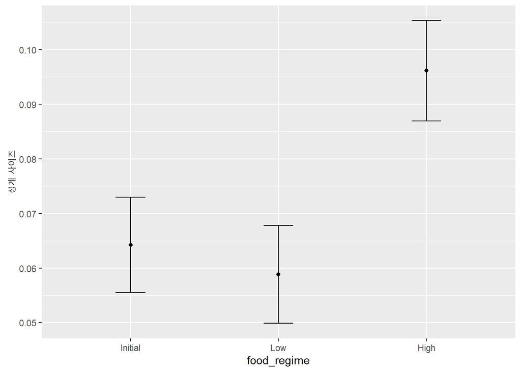

```r
# 그래프
ggplot(plot_data, aes(x = food_regime)) +
  geom_point(aes(y = .pred)) +
  geom_errorbar(aes(ymin = .pred_lower,
                    ymax = .pred_upper),
                width = .2) +
  labs(y = "성게 사이즈")
```

##6. 다른 모델링 적용해보기 지금까지는 회귀분석으로 모두가 만족할만한 결과를 냈다. 하지만 **베이지안 통계**신봉자는 베이지안 모델링을 사용하고 싶을 수 있다.  
보통 이렇게 모델링을 바꿀 경우, 전혀 다른 프로세스와 패키지를 사용해야 한다.하지만 `tidymodel`에서는 유사한 모델피팅 과정을 통해 베이지안 회귀분석을 수행할 수 있다.아래를 보자.  
**베이지안 통계**에서는 사전분포가 필요하다. 만약 분석가들이 이 분포가 [`코시 분포`](https://en.wikipedia.org/wiki/Cauchy_distribution) (자유도가 1인 t 분포) 인 것에 합의했다고 가정하자.

```r
# t사전 분포 정의
prior_dist <- rstanarm::student_t(df = 1)

set.seed(123)

# parsnip 모델 정의
bayes_mod <-
  linear_reg() %>%
  set_engine("stan",
             prior_intercept = prior_dist,
             prior = prior_dist)

# 모델 훈련
bayes_fit <-
  bayes_mod %>%
  fit(width ~ initial_volume * food_regime, data = urchins)

# 결과 보기기
tidy(bayes_fit)
```

```
## # A tibble: 6 x 3
##   term                            estimate std.error
##   <chr>                              <dbl>     <dbl>
## 1 (Intercept)                     0.0331    0.00954
## 2 initial_volume                  0.00155   0.000406
## 3 food_regimeLow                  0.0200    0.0128
## 4 food_regimeHigh                 0.0216    0.0143
## 5 initial_volume:food_regimeLow  -0.00126   0.000516
## 6 initial_volume:food_regimeHigh  0.000530  0.000706
```

1. 먼저 사전분포를 정의했다. 사전분포는 `rstanarm` 패캐지에서 t-분포로 지정한다.
2. `linear_reg()`를 통해 회귀 모델링임을 선언하고 `set_engine`을 통해서 `stan`패키지의 엔진을 도입한다. 이 때 베이지안 통계임을 염두해두고, `prior_intercept`(사전분포 절편)와 `prior`(사전분포)을 함께 정의한다.
3. 똑같이 formula를 적용해 모델을 적합한 후, `tidy()`함수를 통해 결과를 살펴본다. 그냥 결과를 print해서 보는 것 보다 훨씬 정리된 형태로 보여준다.
- `tidymodels()` 패키지의 목적 자체가 **프로세스와 결과의 일관화**이다.

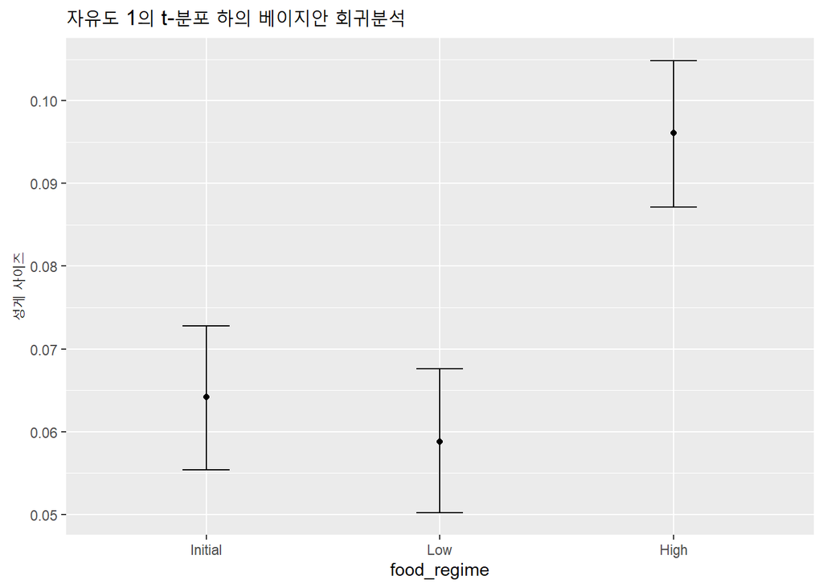

```r
bayes_plot_data <-
  new_points %>%
  bind_cols(predict(bayes_fit, new_data = new_points)) %>%
  bind_cols(predict(bayes_fit, new_data = new_points, type = "conf_int"))

ggplot(bayes_plot_data, aes(x = food_regime)) +
  geom_point(aes(y = .pred)) +
  geom_errorbar(aes(ymin = .pred_lower, ymax = .pred_upper), width = .2) +
  labs(y = "성게 사이즈") +
  ggtitle("자유도 1의 t-분포 하의 베이지안 회귀분석")
```

1. 위 과정은 앞서 진행한 회귀분석의 plot_data 작성 과정과 동일하므로 생략한다.

## 7. 결론

이 패키지를 통해서 우리는 아래와 같은 것을 배울 수 있다. 1. `tidymodels`를 통해서 머신러닝 프로세스를 R 상에서 일원화 할 수 있다. 2. 다른 패키지의 도입 없이 하나의 패키지 플랫폼에서 머신러닝 과정을 처리 가능하다.  
이어지는 정리에서는 `recipe`를 살펴볼 예정이다. 이 패키지는 머신러닝에서 기본적으로 수행하는 여러 전처리 과정을 쉽게 할 수 있도록 도와주는 패키지이다. 이 과정을 통해서 전처리 과정이 얼마나 간단하게 진행되어서 모델링 자체에 집중할 수 있게 되는지 한 번 파악해보자.